# CRM and Loyalty-

CB

26 février 2019

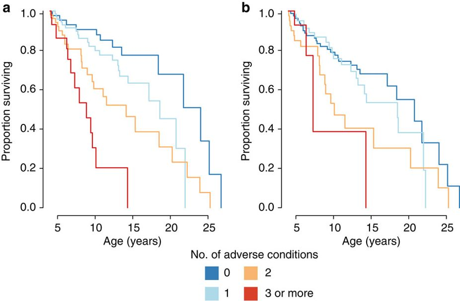

Une vie de babouine

Note[^1]

Si les cartes de fidélité ont moins d’attrait c’est qu’elles se sont multipliées, se concurrencent par le multihoming, et ont du souvent reconsidérer leur plan de gratification à la baisse, réduisant la valeur des points où relevant les seuils de statut, elles n’en restent pas moins le moyen principal pour les marques de suivre la consommation de leurs clients et demeurent un élément clé du système de gestion de la clientèle (CRM). Sans adhésion, sans numéro, il n’y a pas de connaissance client.

Les distributeurs, les compagnies aériennes, les hotels, toutes les industries de services qui délivrent des prestations répétées à la guise du client, prétendent à modifier les achats subséquents en récompensant l’achat actuel. Ceci se traduit par une distribution de points à chaque achat, selon des barème plus ou mois complexes, mais dont on suppose qu’ils peuvent affecter l’achat suivant soit en le précipitant, soit en accroissant sa valeur monétaire.

L’étude qui fait l’objet de ce carnet de note, s’appuie sur un cas caractéristique, et vise à présenter des analyses comportementale de la relation par l’analyse des transactions. Autrement dit la liste des actes d’achat au cours du temps d’une cohorte de consommateursdont une possède une description sommaire.

Elle suit de près une publication encore plus ancienne qui portait sur un cas similaire, et avec une échelle de donnée équivalente BENAVENT and CRIÉ (1998) . On va y retrouver des éléments analogues qui font de cette étude une réplication positive qui confirme la généralité des résultats obtenus il y a bien longtemps.

Cette étude reste cependant méthodologique et pédagogique et vise à détailler des analyses standards de ce type de structure de données, en particulier l’application de modèle de cox pour analyser la durée de vie des porteurs de carte de fidélité, un modèle linaire hiérarchique pour tester l’effet des récompenses acquises et de différents outils graphiques.

# Préparation des données

Les données sont relationnelles, à un niveau minimal. On dispose de 4 fichiers reliés par leur index :

- Un fichier de 5000 clients qui ont adhéré au programme de fidélisation en 2010. Ils forment une cohorte, dont on suit retrospectivement (Le recueil des données est réalisée en 2014) les comportements.
- Un fichier de leur tickets de caisse sur une période de 4 ans, lorsqu’ils ont présenté leur carte en caisse qui représente 57000 passage en caisse dont on connait la date, le client, et le montant.
- un fichier des articles mentionnés dans chaque ticket de caisse (environ 200 000 lignes) et un fichier des références des articles et de leurs catégorie complète de la base, mais on ne les utilisera pas dans l’analyse suivante.

Même simple, cette structure conduit à une gymnastique des données, où pour produire les tableaux à analyser, il va falloir filtrer, merger, agréger. Dans cette esprit on consultera avec profit ce [chapitre d’un excellent ouvrage](https://r4ds.had.co.nz/relational-data.html) et on en profitera pour se mettre sérieusement à `dplyr`

On retiendra de cette structure dans une représentation simple le schéma suivant. Elle se contruit avec trois éléments

- Des individus i qui possèdent des cartaristiques Xi à travers le temps
- Une liste des évenements qui se déroulent après le relevé des caractéristiques des sujets et décrivent leur expérience de consommation.
- Des agrégations qui enrichissent le fichier des individus de caratères comportementale dérivée de la séquence des achat, en particulier la durée écoulée entre le premier achat et le dernier.

## Initialisation

Voici la liste des packages néçessaires pour nos analyses.

```r
knitr::opts_chunk$set(echo = TRUE, include = TRUE,message=FALSE,Warning=FALSE)
library(readr)  # necessaire pour importer les données
library(tidyverse) #la boite à outils qui monte qui monte, indipensable pour les graphique , indiemnsable pour reconstruire les données
library(reshape2) #indispensable pour ggplot
library(readxl) #pour importer des feuilles excel
library(Rcmdr) # si on a besoin d'interactivité
library(survival) #le coeur de notre analyse
library(survminer) #un outil pour bien représen,ter la survie ou le rique
library(lubridate) #bien utile pour manipuler les dates
library(gglorenz) #analyse des concetration autrement la verification des 20:80
library(ineq) # un compment aux analyse de concentratrion
library(jtools)
library(lme4) # pour des regression complese
library(nlme)  # pour des regression complese ma  is d'autres méthodes
library(effects)
library(ape)  #ape est le pacckahe de la phylogénie mais fournit des ressources essentielle pour mieux pratiquer le clusting
library(gridExtra) #question de mettre des graphique dans un meme espace
library(viridis) #pour lmes couleurs
library(knitr)
library(kableExtra)
library(stargazer) #pour comparer les modèles de regression et de survie

#pour arranger les figures en une


#lecture des fichiers
Customer <- read.csv2("~/AtelierR/botanic/Customer.csv", encoding="UTF-8")
Customer<-Customer %>% rename(Adhesion=cl_dateadhesion,Genre=cl_civNorm,Naissance=cl_naissance)

#passage en caisse (ticket)
Purchase<- read.csv2("~/AtelierR/botanic/EXTRACTION_TICKET.csv")
Purchase<-Purchase %>% rename(Montant=tic_totalTTC,Points=tic_pointObtenu,Date=tic_date, magasin=mag_code)
```

Commencons par représenter l’ensemble des données et donc la distribution dans le temps des achats , ou passage en caisse réalisés, par une cohorte d’adhérents à la carte de fidélité.

Compte-tenu de la nature historique des données on utilisera largement le package `lubridate` pour manipuler les dates, les temps et les durées.

```r
Customer$echantillon1<-as.factor(Customer$echantillon1)
Customer$echantillon2<-as.factor(Customer$echantillon2)

Customer$C_sms<-0

Customer$C_sms[Customer$onlysms==1]<-1
Customer$C_sms[Customer$courrier_email_sms==1]<-1
Customer$C_sms[Customer$courrier_sms==1]<-1
Customer$C_sms[Customer$email_sms==1]<-1

Customer$C_email<-0

Customer$C_email[Customer$onlyemail==1]<-1
Customer$C_email[Customer$courrier_email_sms==1]<-1
Customer$C_email[Customer$courrier_email==1]<-1
Customer$C_email[Customer$courrier_sms==1]<-1

Customer$C_mail<-0
Customer$C_mail[Customer$onlymail==1]<-1
Customer$C_mail[Customer$courrier_email_sms==1]<-1
Customer$C_mail[Customer$courrier_email==1]<-1
Customer$C_mail[Customer$courrier_sms==1]<-1

Customer<- Customer[c(-5,-6,-7,-8,-16,-17,-18,-19,-20,-21,-22)]

Customer$idclient<-as.factor(Customer$idclient)
Purchase$idclient<-as.factor(Purchase$idclient)
Purchase$Montant<-as.numeric(Purchase$Montant)

#merge of the customer and c1_pf.
Customer<-subset(Customer,echantillon1==1)
Purchase<-merge(Purchase,Customer, by.x="idclient",by.y="idclient", all.x=FALSE, all.y=FALSE, sort=TRUE)
Purchase<-Purchase[c(-7,-8)]
```

# Description de la série

Pour obtenir un sens plus concrêt des données en voici une représentation simple : le nombre de transactions journalières effectuées par les clients qui ont adopté la carte en 2010 au cours des quatre années suivantes. On y observe : * une saisonnalité prononcée avec un pic au printemps (quand le jardin se prépare) et en décembre quand il faut trouver des idées de cadeaux. * une baisse du nombre absolu des achats qui traduit l’attrition, les membres du programme disparaissent, soit qu’ils n’utilisent plus la carte pour bénéficier des avantages (les points) soit qu’ils ne sont plus clients de l’enseigne.

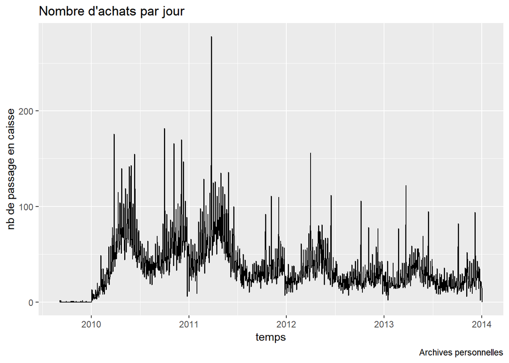

```r
Purchase$Date<-as.POSIXct(Purchase$Date) #un format qu'aime lubridate
g<-Purchase %>%
  ggplot(aes(Date)) +
  geom_freqpoly(binwidth = 86400) + labs(title = "Nombre d'achats par jour",caption = "Archives personnelles",x="temps",y="nb de passage en caisse")
g
```

```r
# le choix du binwidth est justifié par ce que  86400 seconds = 1 day
```

Pour mieux représenter la saisonnalité, identifions le nombre moyen d’achats par jour de la semaine, par jour du mois, et par mois de l’année. On y retrouve un fort rythme saisonnier (avril/mai; décembre), un rythme hebdomadaire qui concentre les ventes le we, et dans une importance moins nette des achats un peu plus denses en début de mois mais c’est à prouver. Les achats se font vers 11h ou 17h.

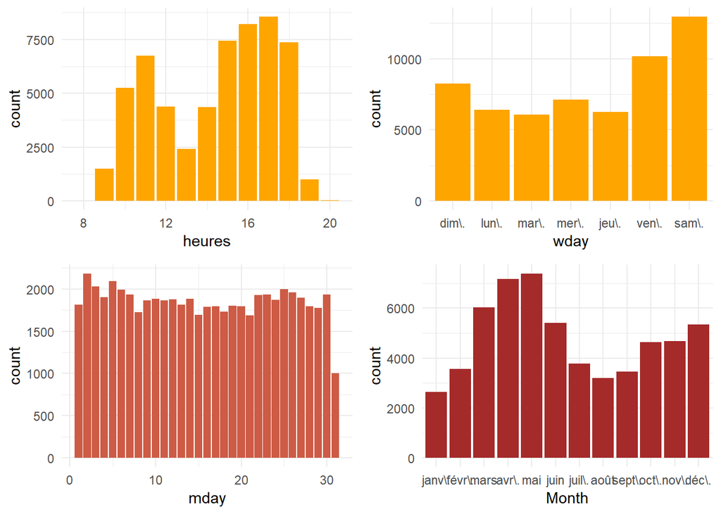

```r
g0<-Purchase %>%
  mutate(heures = hour(Date)) %>%
  ggplot(aes(x = heures)) + geom_bar(fill="orange")+theme_minimal()

g1<-Purchase %>%
  mutate(wday = wday(Date, label = TRUE)) %>%
  ggplot(aes(x = wday)) + geom_bar(fill="orange")+theme_minimal()


g2<-Purchase %>%
  mutate(mday = mday(Date)) %>%
  ggplot(aes(x = mday)) +  geom_bar(fill="coral3")+theme_minimal()

g3<-Purchase %>%
  mutate(Month = month(Date, label = TRUE)) %>%
  ggplot(aes(x = Month)) +geom_bar(fill="brown")+theme_minimal()

grid.arrange(g0,g1,g2,g3,nrow=2)
```

# Analyse de l’attrition

C’est un enjeu essentiel que de comprendre l’attrition des clients. Pour l’apprécier, on emploie les ressource de l’analyse de survie. Comment modéliser les chance qu’un souscripteur à la carte soit toujours client au bout d’une durée t ?

## les durées de vie des clients

Examinons les durées écoulées entre l’adhésion et le dernier achat. On trouve des pics annuels qui correspondent vraisembablement aux dates de renouvellement, ou plutôt de non-renouvelement de la carte. Ils sont à peu près annuel (365 jours). On note naturellement le pic initial correspondant aux achats uniques, ceux qui ont été produit au moment de l’adhésion et n’ont pas fait d’autres achats. Soit que les clients aient disparus, soit qu’ils n’utilisent pas leur carte.

On calcule séparemment sur la base du fichier des achats la plus faible et la plus forte des valeurs ( le premier et le dernier achat) qu’on matche en un fichier donc l’index est l’individu. La durée de vie est calculée en faisant la différente des dates de premier et de dernier achat. Il n’y a plus qu’à examiner l’histogramme des durées de vie ( exprimée en jour).

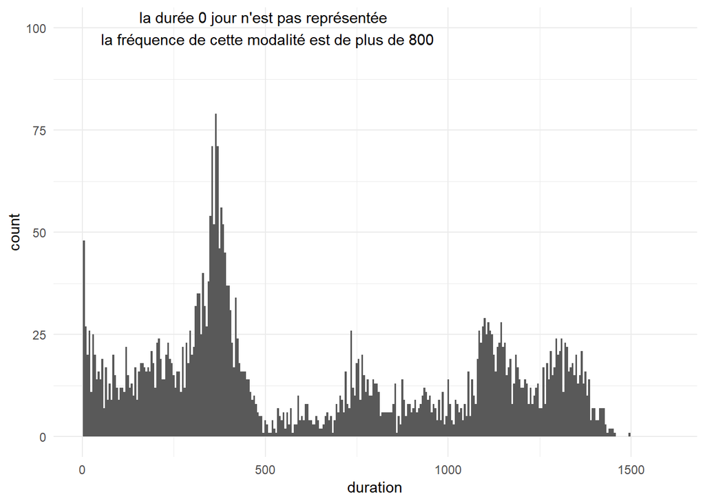

```r
c1<-group_by(Purchase, idclient) %>% summarise(mind = min(Date))
c2<-group_by(Purchase, idclient) %>% summarise(maxd = max(Date))
c1<-cbind(c1,c2[2])

c1<-c1 %>% mutate(duration=as_date(maxd)-as_date(mind))
c1<-as.data.frame(c1)
g<-ggplot(c1,aes(x = duration))+geom_histogram(binwidth =5)+xlim(1,1600)+ annotate("text", x = 500, y = 100, label ="la durée 0 jour n'est pas représentée \n la fréquence de cette modalité est de plus de 800")+theme_minimal()
g
```

## Définition de la variable de censure

Ces données se prêtent parfaitement à des analyses de survie, il faut cependant indiquer si ces durées sont censurée ou pas. Autrement dit quelque soit leur durée, si l’evenement a été observé ou pas. Cet évenement est la disparition du client qui ne refaira plus d’autres achats. S’il n’est pas observé, il est probable que la durée d’échat s’étendra audelà de la date d’observation, mais nous ne le savons pas. La cience des modèles de survie c’est de prendre en compte ce facteur pour donner des estimations qui ne soit pas biaisées. On comprend que si on prend les durée telles quelles, on en minise la durée moyenne.

La censure est donc la variable qui signale si, à la date de l’étude, l’événement s’est produit ou ne s’est pas encore produit, implicant que la durée mesurée est la durée minimale et qu’on en connaît pas encore la valeur exacte. On peut s’appuyer sur deux méthodes :

- la première prend en compte la date de non renouvellement de la carte de fidélité
- la seconde s’appuie sur l’analyse des achat et un critère simple qui est celui d’un critère de décision discrimant les derniers achats marquant l’arrêt définitif, de ceux qui sont simplement les derniers achats observés.

c’est la seconde méthode que l’on choisit. Le critère de décision va s’appuyer sur le calcul d’une durée écoulée entre le dernier achat observé et la date de l’étude pour tenir compte de la variabilité individuelle. Si cette durée est significative plus grande que la durée inter-achat, on en déduit que la probabilité que le client a disparu est élevée.

Mais auparavant représentons ces durées inter-achats pour ceux qui ont réalisé plus de deux achats. On retrouve une distribution centrée sur une trentaine de jour. Le rythme serait ainsi plutôt mensuel.

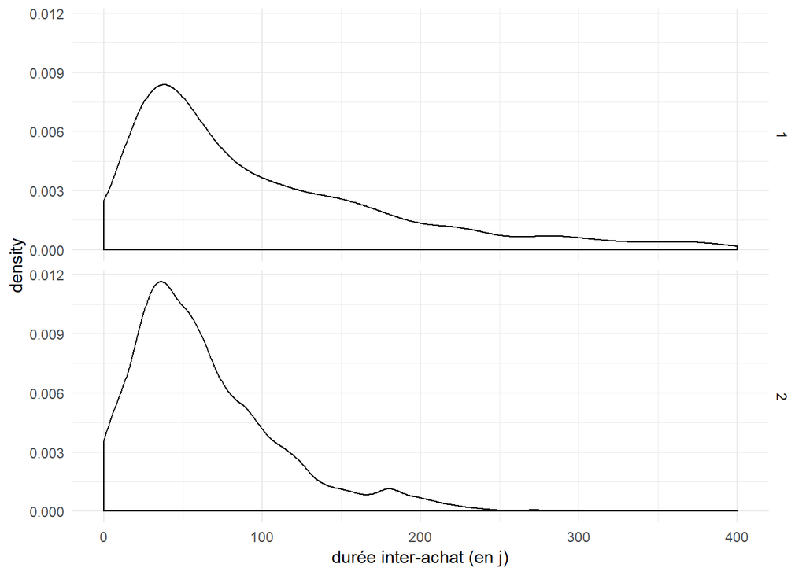

```r
Purchase$n<-1
c2<-aggregate(n~idclient,data=Purchase,sum )
end <- as.POSIXct('2014-1-1') #fixer la date d'étude
#calculer la duree interachat durée-totale/nombre d'achats et la durée ecoulée depuis le dernier achat - ne garder que ceux qui ont fait deux achats
c1<-cbind(c1,c2[2])  %>% mutate(fq=duration/n) %>% mutate(last= end-maxd ) %>% filter(n>1)
#initialiser la censure à 1
c1$censure<-1
#donner la valeur de 2 si la duree ecoulee est superieure à 2x la duree inter achat.
c1$censure[c1$last>2*c1$fq]<-2
c1$censure<-as.factor(c1$censure)
#afficher la distribution des durées interachats
ggplot(c1,aes(x=fq,group=censure))+geom_density(binwidth = 10)+xlim(0,400)+ labs(x = "durée inter-achat (en j)")+theme_minimal()+facet_grid(censure~.)
```

## Une première approche par la méthode de Kaplan-Meyer

Elle est univarié, elle est actuaire, elle représente les données sans explication sauf à comparer des groupes distincts, elle donne l’allure du phénomène. C’est en 1958 qu’elle a été inventée, en voici le [texte fondamental](https://web.stanford.edu/~lutian/coursepdf/KMpaper.pdf), et un [commentaire collector de 1983](http://www.garfield.library.upenn.edu/classics1983/A1983QS51100001.pdf).

```r
c1<-merge(Customer,c1, by.x="idclient",by.y="idclient", all.x=FALSE, all.y=FALSE, sort=TRUE)

#kaplanmeier
c1$SurvObj <- with(c1, Surv(duration, censure == 2))
km <- survfit(SurvObj ~ 1, data = c1, conf.type = "log-log")
km
```

```
## Call: survfit(formula = SurvObj ~ 1, data = c1, conf.type = "log-log")
##
##       n  events  median 0.95LCL 0.95UCL
##    4235    3161     431     419     452
```

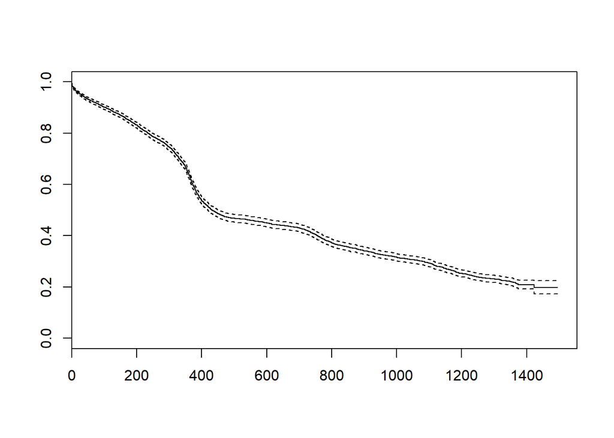

```r
plot(km)
```

# Modèle de Cox

C’est au fond un modèle de régression ou le terme constant est remplacée par une courbe de risque, sa propriété est de conserver au cours du temps les rapports de risque. Sa formalisation est la suivante :

$$h_{it}=h_{0,t}\exp^{X_{i}\beta}$$

On utilise le package `survmining` et pour aller plus loin on consultera avec profits ce [lien](https://www.ncbi.nlm.nih.gov/pmc/articles/PMC5220043/) et le [suivant](http://www.sthda.com/english/wiki/survival-analysis-basics).

Dans la séquence suivante on spécifie le modèle, puis avec la fonction `cox.zph` on evalue la proportionnalité des risques. Les deux denières lignes sont destinées à représenter les courbes de survie et de risque cumulé pour une variable qui attire notre intention. C’est une reprensation stratifiée

```r
#cox
res.cox1 <- coxph(SurvObj ~  C_sms + C_mail + C_email+HABITE+ANIMAUX_chien, data =  c1)
res.cox1
```

```
## Call:
## coxph(formula = SurvObj ~ C_sms + C_mail + C_email + HABITE +
##     ANIMAUX_chien, data = c1)
##
##                               coef exp(coef) se(coef)      z        p
## C_sms                      0.09587   1.10062  0.05209  1.840   0.0657
## C_mail                    -0.44117   0.64328  0.06816 -6.472 9.64e-11
## C_email                   -0.07407   0.92860  0.04543 -1.631   0.1030
## HABITEAPPARTEMENT         -0.04042   0.96039  0.07392 -0.547   0.5845
## HABITEMAISON INDIVIDUELLE -0.08489   0.91861  0.06503 -1.305   0.1918
## ANIMAUX_chien             -0.06376   0.93823  0.04678 -1.363   0.1729
##
## Likelihood ratio test=53.93  on 6 df, p=7.605e-10
## n= 4235, number of events= 3161
```

```r
(res.zph1 <- cox.zph(res.cox1))
```

```
##                                 rho    chisq       p
## C_sms                     -0.006414 1.30e-01 0.71824
## C_mail                     0.052849 8.87e+00 0.00291
## C_email                    0.002906 2.68e-02 0.86990
## HABITEAPPARTEMENT          0.014814 6.90e-01 0.40600
## HABITEMAISON INDIVIDUELLE  0.015073 7.20e-01 0.39620
## ANIMAUX_chien             -0.000134 5.67e-05 0.99399
## GLOBAL                           NA 1.12e+01 0.08098
```

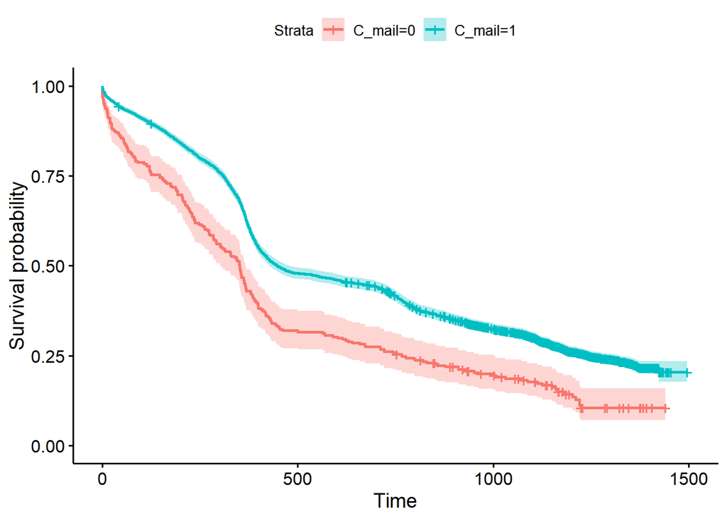

```r
#plot(res.zph1)
c1$duration2<-as.numeric(c1$duration)
fit <- survfit(Surv(duration, censure==2) ~ C_mail, data = c1)
library(survminer)
ggsurvplot(fit, data = c1,conf.int = TRUE)
```

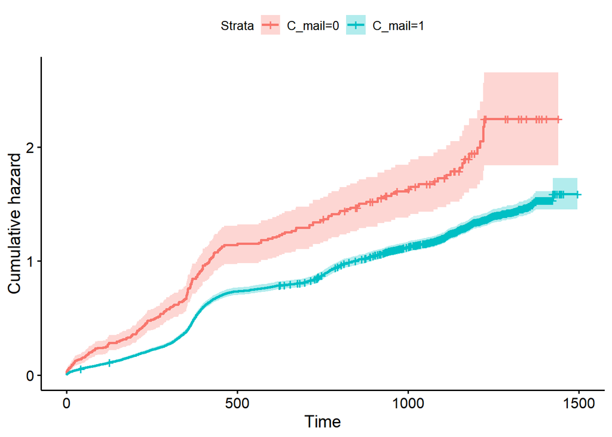

```r
ggsurvplot(fit, data = c1, fun = "cumhaz",conf.int = TRUE)
```

Une variable semble faire la différence : le fait que le souscripteur aie acceptué de donner son addresse terrestre. En acceptant de s’identifier il signale son comportement futur : plus fidèle. On s’apercoit memem quand on examine le diagramme des taux de risque cumulé qu’il échappe à l’exode de la quatrième année.

Les tests de non-proportionnalité sont importants car il permettent de justifier pour les variables introduite dans la partie deterministe du modèle l’idée un effet constant, indépendant du temps. La proportionnalité des taux de risque est fixée dans la nature même du modèle.

Considérons un modèle très simple réduit à une variable binaire : on possède le mail qu’il a donné ou on a pas l’information codé 1 ou 0.Examinons le rapport des risques pour les deux modalités. Le rato des risque est égal à une constante dont la valeur dépend d’un paramètre. Les rapport de risques sont constant.

$$\frac{h_{0,t}\exp^{1\beta}}{h_{0,t}\exp^{0\beta}}= \exp^{\beta}$$

#### Des variables qui varient dans le temps

Les actes d’achats sont ainsi des variables qui varient dans le temps et ont un effet présumés qui se distibuent dans le temps en fonction de leur apparition.

sur un plan pratique on va utiliser des ressources de tmerge qui est une fonction difficile à utiliser. Elle crée les variables dont nous avons besoin : des départs, des fins, des censures, des evenements, pour présenter les données sous une forme qui enregistre les individus et les séquences marqué par un début de vie, des évenements, et une fin de vie ou une censure .

pour structurer les données on emploie la fonction tmerge qui est délicate et complexe à mettre en oeuvres, mais ensuite très éfficace pour construire le fichier de données nécessaires. Ce document est utile pour une [première approche](http://daynebatten.com/2016/01/tmerge-customer-churn-data/) et on consultera la [vignette](https://cran.r-project.org/web/packages/survival/vignettes/timedep.pdf), si necessaire on regardera cette présentation (https://www.google.com/url?sa=t&rct=j&q=&esrc=s&source=web&cd=4&cad=rja&uact=8&ved=2ahUKEwiW58Pc5IbhAhWInxQKHVwACNoQFjADegQIBBAC&url=https%3A%2F%2Fww2.amstat.org%2Fmeetings%2Fsdss%2F2018%2Fonlineprogram%2FViewPresentation.cfm%3Ffile%3D304494.pdf&usg=AOvVaw0RCQfeZHAVih5vsiP8Fszl)

```r
#preparation fichier

c1_f<-c1 %>% filter(duration>0)

c1_pf<-merge(c1_f,Purchase[,1:8],by="idclient", all=FALSE)

c1_pf$time<-round(as.POSIXct(c1_pf$Date)-as.POSIXct('2010-1-1'),0)

newdata <- tmerge(c1_f, c1_f, id = idclient, action = event(duration,censure))

newdata2<- tmerge(newdata,c1_pf, id = idclient, purchase = event(time, Montant), cumul=cumevent(time, Montant))

fit <- coxph(Surv(tstart, tstop, action==2) ~ C_mail +status+purchase, data=newdata2)
fit2 <- coxph(Surv(tstart, tstop, action==2) ~ C_mail +status+purchase+cumul, data=newdata2)


stargazer(fit,fit2,type = "text")
```

```
##
## ================================================================
##                                  Dependent variable:
##                      -------------------------------------------
##                                        tstart
##                               (1)                   (2)
## ----------------------------------------------------------------
## C_mail                     -0.315***              -0.105
##                             (0.067)               (0.067)
##
## statusVIP                  -1.918***             -0.266**
##                             (0.119)               (0.118)
##
## purchase                   -0.016***             -0.017***
##                            (0.0003)              (0.0005)
##
## cumul                                            -0.021***
##                                                   (0.001)
##
## ----------------------------------------------------------------
## Observations                43,669                43,669
## R2                           0.077                 0.175
## Max. Possible R2             0.670                 0.670
## Log Likelihood            -22,485.330           -20,028.090
## Wald Test            3,492.590*** (df = 3) 1,654.240*** (df = 4)
## LR Test              3,509.589*** (df = 3) 8,424.081*** (df = 4)
## Score (Logrank) Test 1,516.030*** (df = 3) 2,120.297*** (df = 4)
## ================================================================
## Note:                                *p<0.1; **p<0.05; ***p<0.01
```

#### Des paramètres qui dépendent du temps

On sait donc introduire dans un modèle de survie, le modèle de Cox, deux types de variables, des variables invariantes au cours du temps qui exercent un effet proportionnel constant au cours tu temps, et d’autres donc la valeur variant au cours du temps peuvent affecter de manière différentielle les espérances de survie.

Si a est positif l’effet s’accroit avec le temps, s’il est négatif il décroit.

C’est ce que nous allons tester.

la modélisation de la dynamique du paramètre est donc fonction de f(t). si c’est une fonction log, on suppose que que le paramètre s’accroit de manière décroissante avec le temps. si c’est une fonction exp c’est une croissance ou décroissance exponentielle selon le signe.

```r
#cox
res.cox1 <- coxph(SurvObj ~  HABITE+ANIMAUX_chien+ C_sms +C_email + C_mail +tt(C_mail), data =  c1, tt = function(x, t, ...) x * log(t+1))
res.cox1
```

```
## Call:
## coxph(formula = SurvObj ~ HABITE + ANIMAUX_chien + C_sms + C_email +
##     C_mail + tt(C_mail), data = c1, tt = function(x, t, ...) x *
##     log(t + 1))
##
##                               coef exp(coef) se(coef)      z        p
## HABITEAPPARTEMENT         -0.04136   0.95948  0.07392 -0.560 0.575811
## HABITEMAISON INDIVIDUELLE -0.08666   0.91699  0.06502 -1.333 0.182604
## ANIMAUX_chien             -0.06354   0.93843  0.04678 -1.358 0.174399
## C_sms                      0.09590   1.10065  0.05208  1.842 0.065548
## C_email                   -0.07450   0.92820  0.04541 -1.641 0.100887
## C_mail                    -1.25848   0.28408  0.22527 -5.586 2.32e-08
## tt(C_mail)                 0.15304   1.16537  0.04123  3.712 0.000205
##
## Likelihood ratio test=66.57  on 7 df, p=7.278e-12
## n= 4235, number of events= 3161
```

```r
#plot(res.zph1)
```

# analyse des tickets de Caisse

Revenons à l’analyse des transactions, et examinons leurs distribution en fonction des montants. Elle semble suivre une loi exponentielle, ou puissance. On observe des valeurs négatives qui correspondent à des erreurs ou des remboursements.

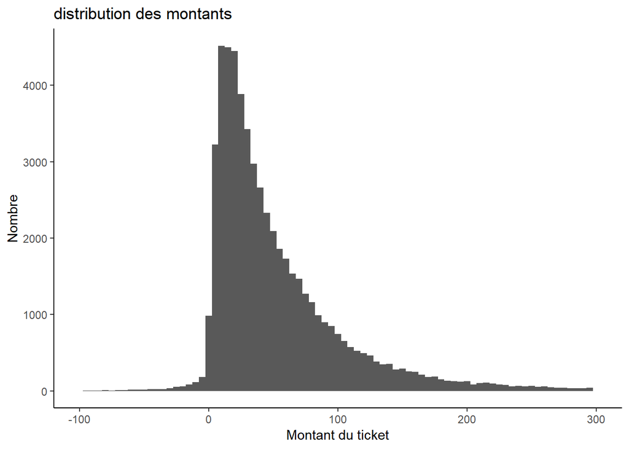

```r
ggplot(c1_pf, aes(Montant)) + geom_histogram(binwidth=5)+
labs(title="distribution des montants",
     y = "Nombre", x="Montant du ticket")+theme_classic()+xlim(-100, 300)
```

On ne prendra en compte que des valeurs strictement positives.

On exclue de l’analyse les achats opportunistes, ceux qui n’ont lieu qu’une fois et incite à prendre la carte de fidélité pour bénéficier d’un avantage immédiat.La carte joue pour ces clients le rôle d’une promotion. On pourrait s’interroger du la proportion d’entre eux qui aurait réaliser l’achat sans cette opportunité.

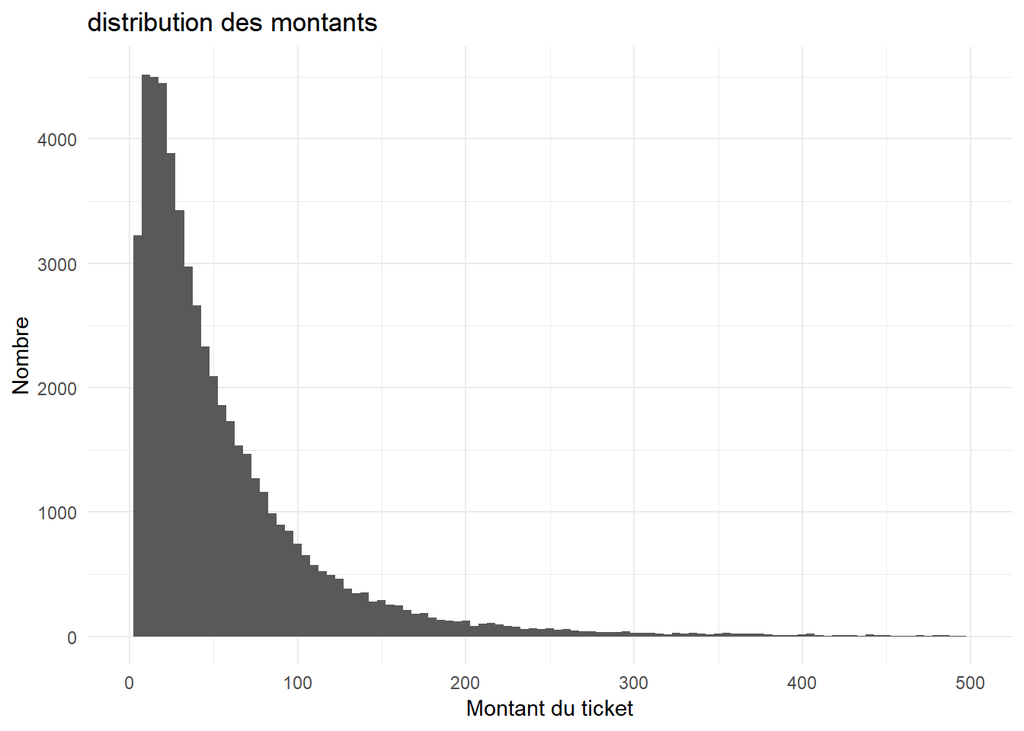

```r
#c1_pf<-merge(c1_pf,c1, by="idclient",all.x=FALSE, all.y=FALSE, sort=TRUE)%>%filter(Montant>0)%>% filter(n.y>1)

ggplot(c1_pf, aes(Montant)) + geom_histogram(binwidth=5)+
labs(title="distribution des montants",
     y = "Nombre", x="Montant du ticket")+theme_minimal() +xlim(0, 500)
```

La bonne vieille loi du commerce : 20% des clients font 80% du chiffre d’affaire et de la marge et cette idée de concentrer sur eux l’essentiel des efforts même s’ils sont aussi la cible des concurrent. cette règle qui conduit à s’exposer à la disruption par une qualité excessive.

Cette loi de concentration est celle que représente la courbe de lorentz : https://en.wikipedia.org/wiki/Lorenz_curve. On utilise à cette fin le package [gglorenz] (avec le package https://github.com/jjchern/gglorenz)

l’enjeu c’est de mesurer la concentration du CA par les ventes les plus élevées.

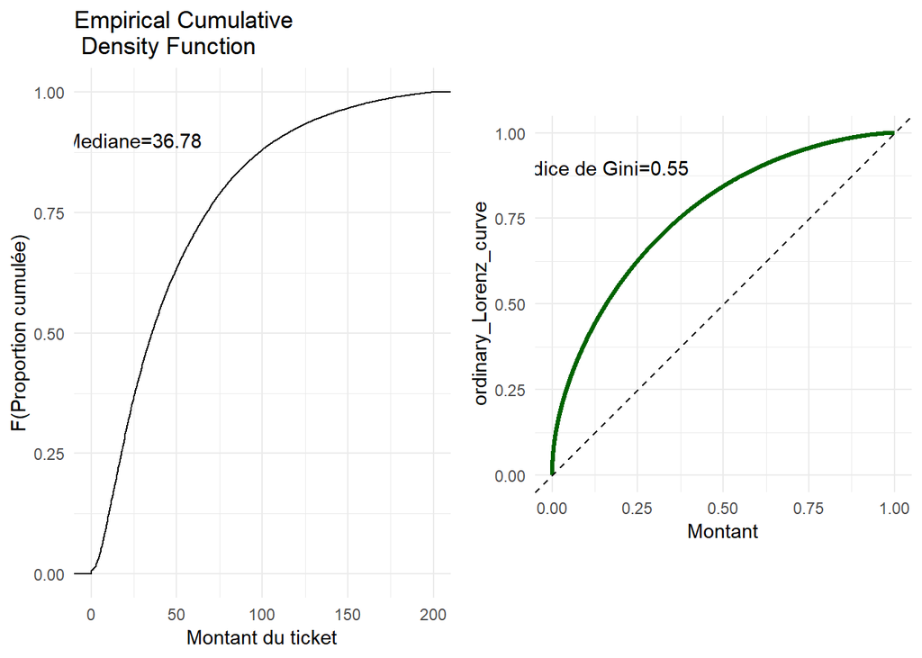

```r
Mediane<-round(median(c1_pf$Montant,na.rm = TRUE),2)
g1<-ggplot(c1_pf, aes(Montant)) + stat_ecdf(geom = "step")+
labs(title="Empirical Cumulative \n Density Function",y = "F(Proportion cumulée)", x="Montant du ticket")+theme_minimal()+xlim(0, 200)+ annotate("text", x=25, y=0.9, label= paste0("Mediane=",Mediane))


gini<-round(ineq(c1_pf$Montant,type = c("Gini")),2)

c1_pf<-c1_pf %>% filter(Montant>0)
g2<-ggplot(c1_pf, aes(Montant)) +stat_lorenz(desc = TRUE,size=1.2,color="Darkgreen") +coord_fixed() +geom_abline(linetype = "dashed") +theme_minimal() + annotate("text", x=0.15, y=0.9, label= paste0("indice de Gini=",gini))

library(gridExtra)
grid.arrange(g1,g2,ncol=2)
```

## Evolution des montants au cours du temps

On y retrouve le même phénomène.

Pour les montant d’achats, quelques soit les consommateurs classés en termes de nombre d’achat réalisé sur la période, on observe un effet sur les premières périodes : le montant est maximal au premier achat, il se réduit sur une séquence de deux ou trois achats, puis se maintient à un niveau stationnaire qui ne dépend pas de la segmentation.

En explorant avec une courbe d’ajustement lissée, on s’aperçoit que les clients qui produiront le plus d’achats sont moins affectés par l’effets d’opportunités, leur dépenses moyennes sont moins elevées que ceux qui ne feront que quelques achats. Mais tous se rejoignent au niveau stationnaire.dès le 4ème ou cinquième achat.

```r
Seq1 <- c1_pf[order(c1_pf$idclient,c1_pf$Date),]
Seq1 <-Seq1%>% group_by(idclient)%>% mutate(rank = dense_rank(Date))%>% ungroup()
Seq1$Classe_freq[Seq1$n==2] <-"2 achats"
```

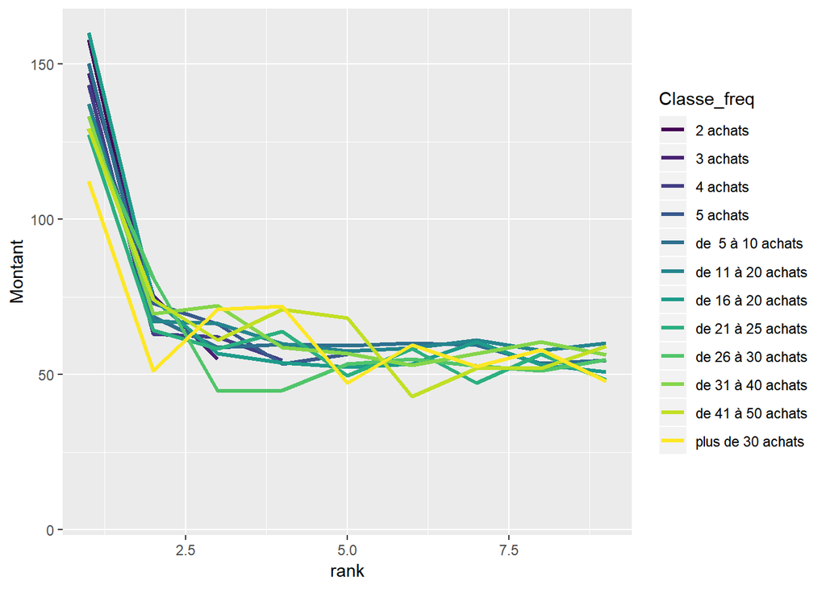

```r
Seq1$Classe_freq[Seq1$n==3] <-"3 achats"
Seq1$Classe_freq[Seq1$n==4] <-"4 achats"
Seq1$Classe_freq[Seq1$n==5] <-"5 achats"
Seq1$Classe_freq[Seq1$n>5 & Seq1$n<11 ] <-"de  5 à 10 achats"
Seq1$Classe_freq[Seq1$n>10 & Seq1$n<16 ] <-"de 11 à 20 achats"
Seq1$Classe_freq[Seq1$n>15 & Seq1$n<21 ] <-"de 16 à 20 achats"
Seq1$Classe_freq[Seq1$n>20 & Seq1$n<26 ] <-"de 21 à 25 achats"
Seq1$Classe_freq[Seq1$n>25 & Seq1$n<31 ] <-"de 26 à 30 achats"
Seq1$Classe_freq[Seq1$n>30 & Seq1$n<41 ] <-"de 31 à 40 achats"
Seq1$Classe_freq[Seq1$n>40 & Seq1$n<51 ] <-"de 41 à 50 achats"
Seq1$Classe_freq[Seq1$n>50] <-"plus de 30 achats"

Seq2<-aggregate(Montant~rank+Classe_freq,data=Seq1,FUN=mean)
Seq2$Classe_freq<-as.factor(Seq2$Classe_freq)

ggplot(Seq2,aes(x=rank,y=Montant,group=Classe_freq))+geom_line(aes(color=Classe_freq),size=1.1)+xlim(0,30)+scale_color_viridis(discrete = TRUE)+xlim(1,9)
```

```r
fit<-lm(log(Montant)~rank+Classe_freq,data=Seq1)
summary(fit)
```

```
##
## Call:
## lm(formula = log(Montant) ~ rank + Classe_freq, data = Seq1)
##
## Residuals:
##     Min      1Q  Median      3Q     Max
## -6.8548 -0.6476  0.0491  0.6920  4.6310
##
## Coefficients:
##                                Estimate Std. Error t value Pr(>|t|)
## (Intercept)                   4.2182373  0.0314436 134.152  < 2e-16 ***
## rank                         -0.0041084  0.0002223 -18.481  < 2e-16 ***
## Classe_freq3 achats          -0.2305502  0.0430184  -5.359 8.39e-08 ***
## Classe_freq4 achats          -0.3871018  0.0411897  -9.398  < 2e-16 ***
## Classe_freq5 achats          -0.4249959  0.0409475 -10.379  < 2e-16 ***
## Classe_freqde  5 à 10 achats -0.4895213  0.0336347 -14.554  < 2e-16 ***
## Classe_freqde 11 à 20 achats -0.5403062  0.0340039 -15.890  < 2e-16 ***
## Classe_freqde 16 à 20 achats -0.5939521  0.0345464 -17.193  < 2e-16 ***
## Classe_freqde 21 à 25 achats -0.5402427  0.0353234 -15.294  < 2e-16 ***
## Classe_freqde 26 à 30 achats -0.6358405  0.0356450 -17.838  < 2e-16 ***
## Classe_freqde 31 à 40 achats -0.5535701  0.0346322 -15.984  < 2e-16 ***
## Classe_freqde 41 à 50 achats -0.5589418  0.0348961 -16.017  < 2e-16 ***
## Classe_freqplus de 30 achats -0.6499348  0.0341970 -19.006  < 2e-16 ***
## ---
## Signif. codes:  0 '***' 0.001 '**' 0.01 '*' 0.05 '.' 0.1 ' ' 1
##
## Residual standard error: 1.025 on 55218 degrees of freedom
## Multiple R-squared:  0.03028,    Adjusted R-squared:  0.03007
## F-statistic: 143.7 on 12 and 55218 DF,  p-value: < 2.2e-16
```

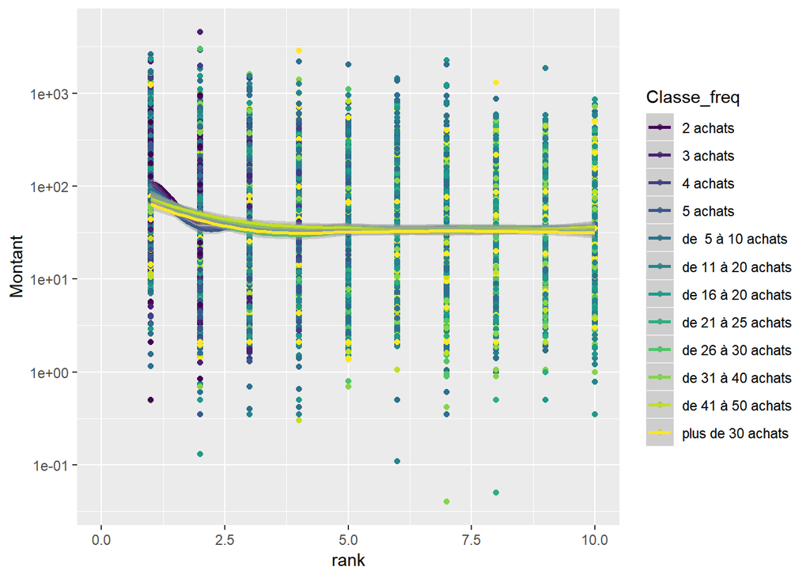

```r
g<-ggplot(Seq1, aes(x=rank,y=Montant,group=Classe_freq))+geom_point(aes(color=Classe_freq))+geom_smooth(method = "loess",aes(color=Classe_freq))+xlim(0,10)+scale_color_viridis(discrete = TRUE)+scale_y_continuous(trans='log10')
suppressWarnings(print(g))
```

## Evolution des durées inter-achat au cours du temps

Pour analyser l’évolution des durées inter-achats, on calcule pour chaque segment définis par le nombre total d’achat des ajustements lissés à l’ordre de l’acte d’achat. En procédant ainsi on contrôle l’effet de la succession de l’effet de fréquence propre à chaque individu.

Un modèle de régression simple complète l’analyse descriptive. Il y a bien un effet d’interaction mais faible, en-deça de la quinzaine d’achat. Les achats fréquents, ceux des vrais fidèles, ont une période stationnaire.

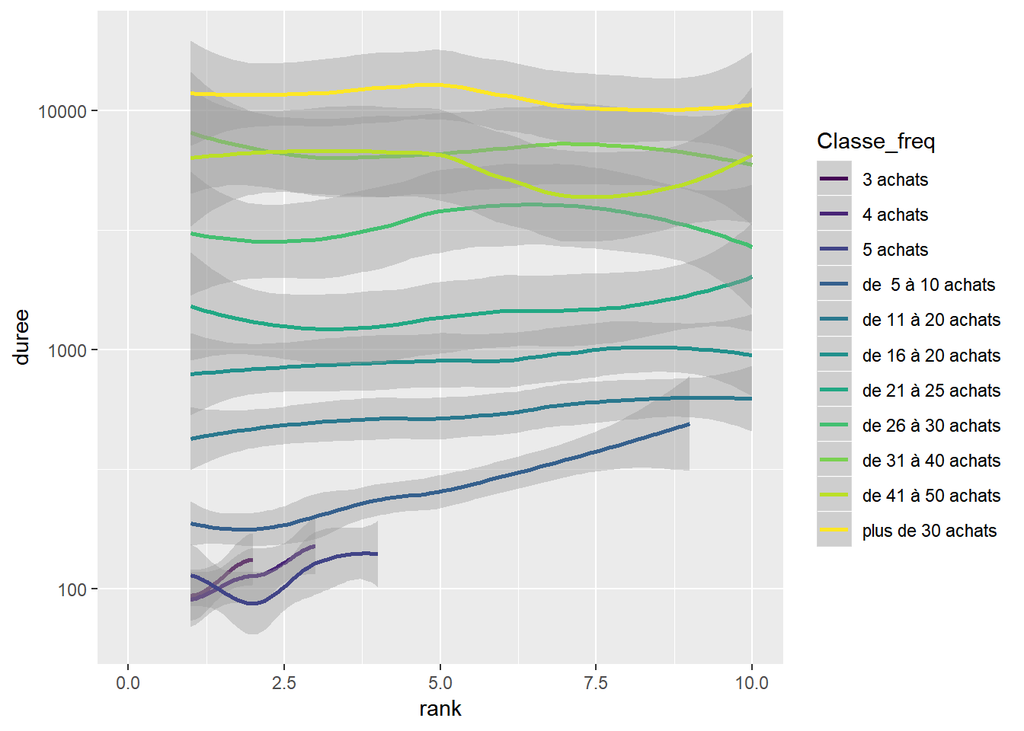

```r
pts<-Seq1 %>% group_by(idclient) %>% mutate(Points, ptscum = cumsum(Points))%>% mutate(Montant, prev = lead(Montant, order_by = rank))%>%  mutate(Date, duree = as.numeric(lead(Date, order_by = rank)-Date)) %>% ungroup()


g<-ggplot(pts, aes(x=rank,y=duree,group=Classe_freq))+geom_smooth(method = "loess",aes(color=Classe_freq))+xlim(0,10)+scale_color_viridis(discrete = TRUE)+scale_y_continuous(trans='log10')
suppressWarnings(print(g))
```

```r
fit1<-lm(log(duree+1)~rank+Classe_freq,data=pts)

fit2<-lm(log(duree+1)~rank+Classe_freq +rank*Classe_freq,data=pts)
stargazer(fit1,fit2,type="text")
```

```
##
## =========================================================================================
##                                                     Dependent variable:
##                                   -------------------------------------------------------
##                                                       log(duree + 1)
##                                               (1)                         (2)
## -----------------------------------------------------------------------------------------
## rank                                       0.006***                    0.004***
##                                             (0.001)                     (0.001)
##
## Classe_freq3 achats                          0.128                      -0.357
##                                             (0.207)                     (0.439)
##
## Classe_freq4 achats                          0.156                      -0.332
##                                             (0.196)                     (0.334)
##
## Classe_freq5 achats                          0.151                      -0.082
##                                             (0.193)                     (0.304)
##
## Classe_freqde 5 à 10 achats                0.859***                     0.432**
##                                             (0.168)                     (0.188)
##
## Classe_freqde 11 à 20 achats               1.726***                    1.424***
##                                             (0.169)                     (0.190)
##
## Classe_freqde 16 à 20 achats               2.255***                    2.101***
##                                             (0.170)                     (0.195)
##
## Classe_freqde 21 à 25 achats               2.772***                    2.470***
##                                             (0.172)                     (0.201)
##
## Classe_freqde 26 à 30 achats               3.494***                    3.412***
##                                             (0.173)                     (0.204)
##
## Classe_freqde 31 à 40 achats               4.158***                    4.109***
##                                             (0.170)                     (0.192)
##
## Classe_freqde 41 à 50 achats               4.111***                    3.985***
##                                             (0.171)                     (0.193)
##
```

[output cut: 32 more lines]

```
##
## rank:Classe_freqplus de 30 achats
##
##
## Constant                                   4.624***                    4.626***
##                                             (0.161)                     (0.161)
##
## -----------------------------------------------------------------------------------------
## Observations                                51,036                      51,036
## R2                                           0.158                       0.159
## Adjusted R2                                  0.158                       0.159
## Residual Std. Error                   3.692 (df = 51023)          3.690 (df = 51013)
## F Statistic                       799.558*** (df = 12; 51023) 439.139*** (df = 22; 51013)
## =========================================================================================
## Note:                                                         *p<0.1; **p<0.05; ***p<0.01
```

# l’effet des points de fidélité

Dans cette troisème partie de l’étude nous reste à étudier l’effet de la distribution des points de fidélité sur d’une part les dépenses éffectuées au cours des prochains achats, et d’autres part sur la fréquence de répétition, autrement dit sur la durée inter-achat.

Il s’agira de mieux apprécier les programmes de fidélisation moins dans leur capacité à segmenter et donc à choisir en connaissance de cause là où il faut investir, mais dans l’appréciation de l’ampleur de leur réponse à l’égard des récompenses qui leurs sont accordées.

## Effets des points gagnés sur le montant des dépenses

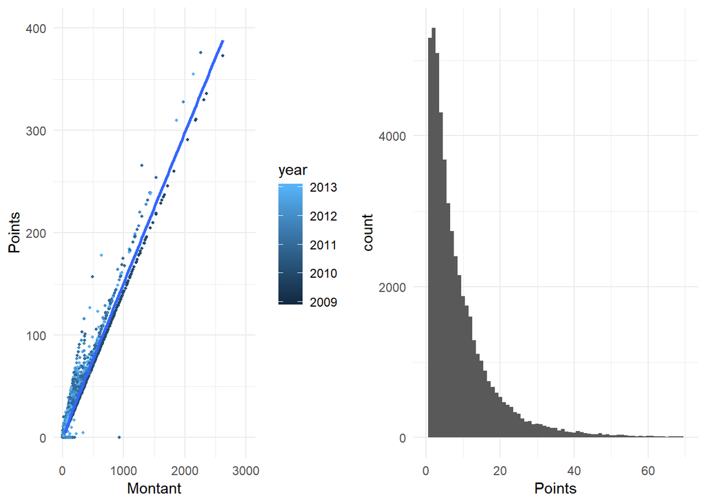

```r
gp1<-ggplot(Seq1, aes(x=Points))+geom_histogram(binwidth = 1)+xlim(0, 70)+theme_minimal()
Seq1$year<-year(Seq1$Date)
gp2<-ggplot(Seq1, aes(x=Montant, y=Points, color=year))+geom_point(size=0.8)+xlim(0,3000)+ylim(0, 400)+theme_minimal()+geom_smooth()
grid.arrange(gp2,gp1,ncol=2)
```

On doit jouer sur le temps, effet des points acquis ou cumulé à t sur les ventes à t+1

l’interaction se produit aussi avec le rang de l’achat, l’effet des point obtenu est positif quand le rang est faible, il devient même négatif quand il est élevé.

```r
pts<-Seq1 %>% group_by(idclient) %>% mutate(Points, ptscum = cumsum(Points))%>% mutate(Montant, total_1 = lag(Montant, order_by = rank))%>% ungroup()
sum(is.na(pts$ptscum))
```

```
## [1] 0
```

```r
sum(is.na(pts$total_1))
```

```
## [1] 4195
```

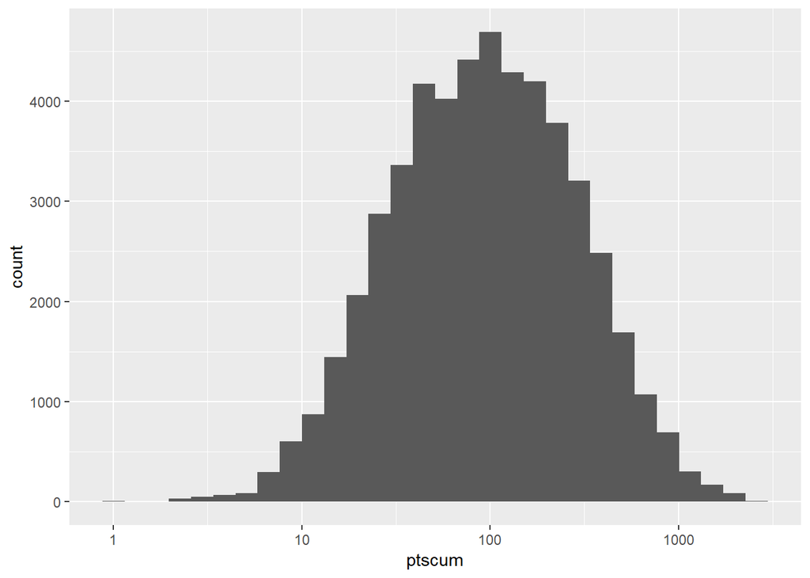

```r
pts<-pts %>% drop_na(total_1)

ggplot(pts, aes(x=ptscum))+geom_histogram()+scale_x_continuous(trans='log10')
```

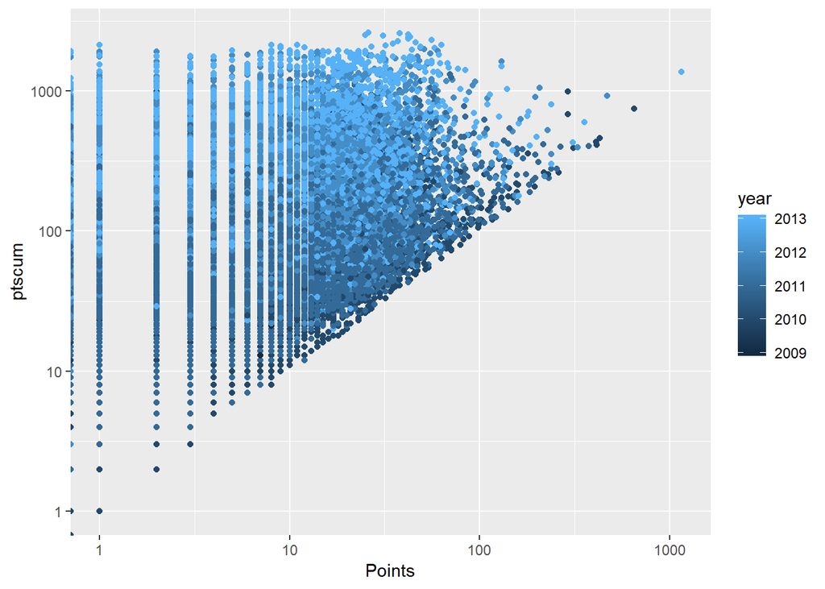

```r
ggplot(pts, aes(x=Points, y=ptscum , color=year))+geom_point()+scale_x_continuous(trans='log10')+scale_y_continuous(trans='log10')
```

```r
#pts$ptscum_sq <- with(pts, cut(ptscum, breaks=quantile(ptscum, probs=seq(0,1, by=0.20), na.rm=TRUE), include.lowest=TRUE))


M1<-lmer(total_1~Montant+Points+ptscum +(Points | idclient),data=pts)
summary(M1)
```

```
## Linear mixed model fit by REML ['lmerMod']
## Formula: total_1 ~ Montant + Points + ptscum + (Points | idclient)
##    Data: pts
##
## REML criterion at convergence: 608892.3
##
## Scaled residuals:
##    Min     1Q Median     3Q    Max
## -8.139 -0.346 -0.137  0.137 37.526
##
## Random effects:
##  Groups   Name        Variance Std.Dev. Corr
##  idclient (Intercept) 3146.160 56.091
##           Points         1.177  1.085   -0.16
##  Residual             7857.368 88.642
## Number of obs: 51036, groups:  idclient, 4177
##
## Fixed effects:
##              Estimate Std. Error t value
## (Intercept) 70.727771   1.185873  59.642
## Montant      0.256845   0.030199   8.505
## Points      -1.220701   0.181704  -6.718
## ptscum       0.014243   0.002969   4.797
##
## Correlation of Fixed Effects:
##         (Intr) Montnt Points
## Montant -0.192
## Points   0.080 -0.956
## ptscum  -0.230  0.122 -0.132
## convergence code: 0
## Model is nearly unidentifiable: very large eigenvalue
##  - Rescale variables?
```

```r
#avec nmle
M2<-lme(total_1~ptscum+Points+Points*rank+Points*ptscum,random=~1|magasin/idclient/rank,data=pts)
summary(M2)
```

```
## Linear mixed-effects model fit by REML
##  Data: pts
##        AIC      BIC    logLik
##   608566.3 608654.7 -304273.2
##
## Random effects:
##  Formula: ~1 | magasin
##         (Intercept)
## StdDev:    6.653273
##
##  Formula: ~1 | idclient %in% magasin
##         (Intercept)
## StdDev:    25.57821
##
##  Formula: ~1 | rank %in% idclient %in% magasin
##         (Intercept) Residual
## StdDev:    89.73589  19.1659
##
## Fixed effects: total_1 ~ ptscum + Points + Points * rank + Points * ptscum
##                  Value Std.Error    DF   t-value p-value
## (Intercept)   60.95111 1.1909707 45762  51.17768       0
## ptscum         0.15518 0.0043099    -3  36.00634     NaN
## Points         0.73524 0.0451098    -3  16.29886     NaN
## rank          -1.14297 0.0359961 45762 -31.75248       0
## Points:rank   -0.02584 0.0020713    -3 -12.47444     NaN
## ptscum:Points -0.00010 0.0000848    -3  -1.23377     NaN
##  Correlation:
##               (Intr) ptscum Points rank   Pnts:r
## ptscum        -0.152
## Points        -0.320  0.088
## rank          -0.086 -0.702  0.072
## Points:rank    0.063 -0.120 -0.161 -0.201
## ptscum:Points  0.151 -0.136 -0.472  0.184 -0.608
##
## Standardized Within-Group Residuals:
##         Min          Q1         Med          Q3         Max
## -1.21157507 -0.07843534 -0.03372290  0.03052797  9.21475168
##
## Number of Observations: 51036
## Number of Groups:
##                         magasin           idclient %in% magasin
##                              65                            5272
## rank %in% idclient %in% magasin
##                           51035
```

```r
#avec log
pts_ln<-pts %>%mutate(total_1_L=log(total_1+1),Montant_l=log(Montant+1), Points_l=log(Points+1),ptscum_l=log(ptscum+1),rank_l=log(rank+1))
M3<-lme(total_1_L~ptscum+Points_l+Points_l*rank_l+Points_l,random=~1|magasin/idclient/rank,data=pts_ln)
summary(M3)
```

```
## Linear mixed-effects model fit by REML
##  Data: pts_ln
##        AIC      BIC   logLik
##   131454.6 131534.2 -65718.3
##
## Random effects:
##  Formula: ~1 | magasin
##         (Intercept)
## StdDev:   0.0765057
##
##  Formula: ~1 | idclient %in% magasin
##         (Intercept)
## StdDev:   0.2808187
##
##  Formula: ~1 | rank %in% idclient %in% magasin
##         (Intercept) Residual
## StdDev:   0.6711507 0.523509
##
## Fixed effects: total_1_L ~ ptscum + Points_l + Points_l * rank_l + Points_l
##                     Value   Std.Error    DF   t-value p-value
## (Intercept)      4.134289 0.028481614 45762 145.15642       0
## ptscum           0.001675 0.000036362    -2  46.07082     NaN
## Points_l         0.202019 0.012518335    -2  16.13789     NaN
## rank_l          -0.348525 0.010692512 45762 -32.59523       0
## Points_l:rank_l -0.050516 0.004726879    -2 -10.68705     NaN
##  Correlation:
##                 (Intr) ptscum Pnts_l rank_l
## ptscum           0.176
## Points_l        -0.772  0.098
## rank_l          -0.848 -0.357  0.694
## Points_l:rank_l  0.699 -0.164 -0.930 -0.719
##
## Standardized Within-Group Residuals:
##         Min          Q1         Med          Q3         Max
## -3.02876082 -0.37972455  0.03541354  0.39990950  3.03951234
##
## Number of Observations: 51036
## Number of Groups:
##                         magasin           idclient %in% magasin
##                              65                            5272
## rank %in% idclient %in% magasin
##                           51035
```

```r
stargazer(M1,M2,M3, type="text")
```

```
##
## =============================================================
##                                Dependent variable:
##                     -----------------------------------------
##                               total_1             total_1_L
##                        linear        linear        linear
##                     mixed-effects mixed effects mixed effects
##                          (1)           (2)           (3)
## -------------------------------------------------------------
## Montant               0.257***
##                        (0.030)
##
## Points                -1.221***       0.735
##                        (0.182)       (0.045)
##
## rank                                -1.143***
##                                      (0.036)
##
## Points:rank                          -0.026
##                                      (0.002)
##
## ptscum:Points                        -0.0001
##                                     (0.0001)
##
## ptscum                0.014***        0.155         0.002
##                        (0.003)       (0.004)      (0.00004)
##
## Points_l                                            0.202
##                                                    (0.013)
##
## rank_l                                            -0.349***
##                                                    (0.011)
##
## Points_l:rank_l                                    -0.051
##                                                    (0.005)
##
## Constant              70.728***     60.951***     4.134***
##                        (1.186)       (1.191)       (0.028)
##
## -------------------------------------------------------------
## Observations           51,036        51,036        51,036
## Log Likelihood      -304,446.100  -304,273.200   -65,718.300
## Akaike Inf. Crit.    608,908.300   608,566.300   131,454.600
## Bayesian Inf. Crit.  608,979.000   608,654.700   131,534.200
## =============================================================
## Note:                             *p<0.1; **p<0.05; ***p<0.01
```

```r
#avec le package Ape
v <- varcomp(M2, TRUE, FALSE)
v
```

```
##    magasin   idclient       rank     Within
## 0.00485460 0.07175018 0.88311044 0.04028478
## attr(,"class")
## [1] "varcomp"
```

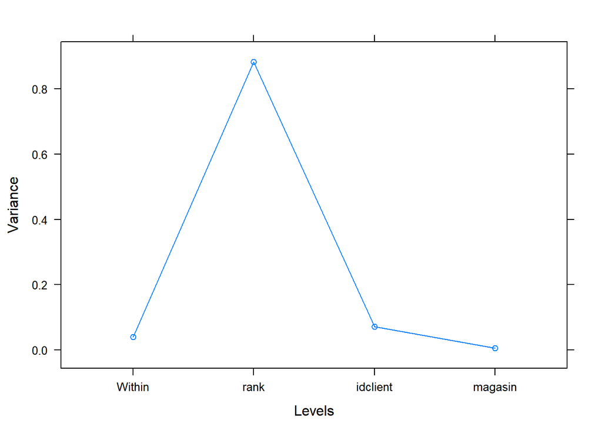

```r
plot(v)
```

```r
library(MuMIn)

r.squaredGLMM(M2)
```

```
##             R2m       R2c
## [1,] 0.07673761 0.9628066
```

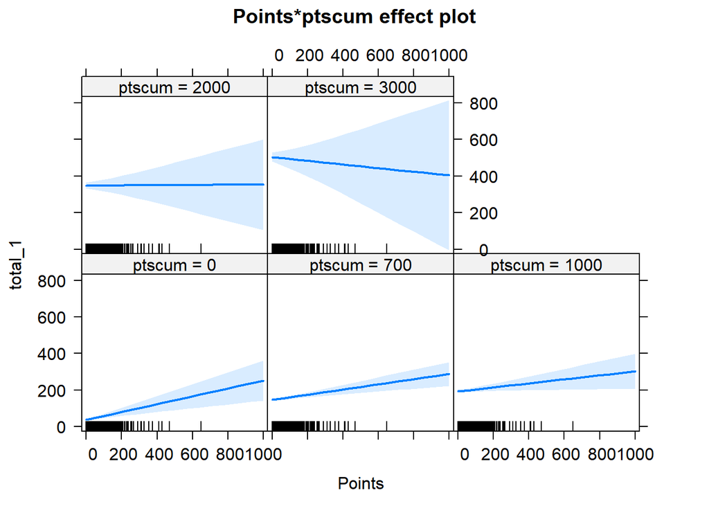

```r
ef <- Effect(c("Points","ptscum"), M2)
plot(ef)
```

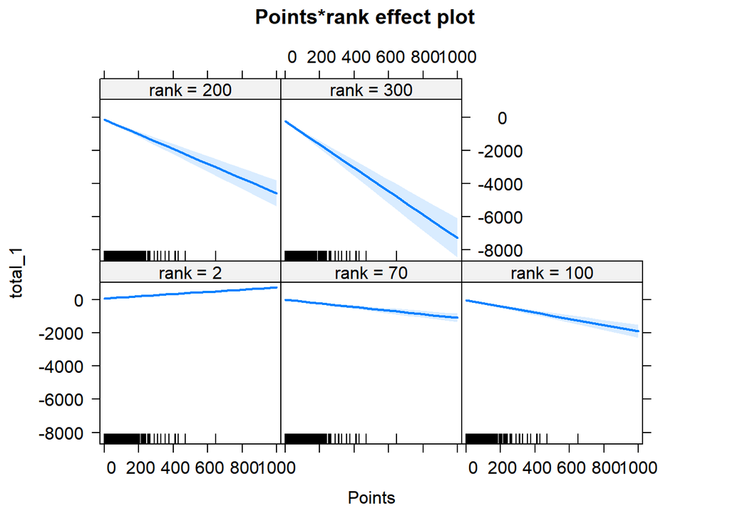

```r
ef <- Effect(c("Points","rank"),quantiles=seq(0, 1, by=0.25), M2)
plot(ef)
```

## Effets des points gagnés sur la durée inter achat

On laisse le soin au lecteur d’ajuster le code précédent à l’étude des durées inter-achat.

# Conclusion

Deux outils complémentaires pour analyser la dynamique des ventes d’un segment adhérant à un programme de fidélisation à deux niveau d’analyse :

- le niveau des transactions : en classant selon l’ordre des achats consruire des modèle linéaire à variable retardée ( on explitique t+1 avec t), et en particilier des modèles linéaires hieracharqui pour décomposer la variance résiduelles dans ses différentes sources hypothétoique : la géographie avec le poitn de vente, l’hétérogénéité individuelle ( les individus), et même le rang de l’achat qui indique au moins une expérience grandissant avec le temps et les expériences de la marque.
- le niveau de la relation : au niveau de la relation : comparaison entre des strates, efet statique (systématique au cours du temps) des variables, modélisation de l’effet de variables qui évoluent au cours du temps, en renant en compte des effets instantanés et des effets cumulés, enfin la modélisation de paramètres qui varient dans le temps.

BENAVENT, CHRISTOPHE, and DOMINIQUE CRIÉ. 1998. “MESURER L’EFFICACITÉ DES CARTES DE FIDÉLITÉ.” *Décisions Marketing*, no. 15: 83–90. http://www.jstor.org/stable/40592920.

Meyer-Waarden, Lars, and Christophe Benavent. 2006. “The Impact of Loyalty Programmes on Repeat Purchase Behaviour.” *Journal of Marketing Management* 22 (1-2): 61–88. doi:10.1362/026725706776022308.

———. 2009. “Grocery Retail Loyalty Program Effects: Self-Selection or Purchase Behavior Change?” *Journal of the Academy of Marketing Science* 37 (3): 345–58. doi:10.1007/s11747-008-0123-z.

Tung, Jenny, Elizabeth A. Archie, Jeanne Altmann, and Susan C. Alberts. 2016. “Cumulative Early Life Adversity Predicts Longevity in Wild Baboons.” *Nature Communications* 7 (April): 11181. https://doi.org/10.1038/ncomms11181.

[^1]: tiré de Tung et al. (2016), les deux courbes represente la survie de babouine exposé à 1, 2 ou plus conditions adverses